# COMPSCIX 415.2 Homework 7

Lionel Armstrong

March 18, 2018

```r
library(mdsr)
library(tidyverse)
library(broom)
library(dbplyr)
library(ggplot2)
library(mosaicData)
library(plyr)
library(dplyr)
library(gridExtra)
library(scales)
```

# Exercise 1

Load the train.csv dataset into R. How many observations and columns are there?

```r
train_data <- read_csv('C:/Rdata/train.csv')
```

##### ANSWER

Observations: 1,460 Variables: 81

# Exercise 2

*Normally at this point you would spend a few days on EDA, but for this homework we will get right to ﬁtting some linear regression models. Our ﬁrst step is to randomly split the data into train and test datasets. We will use a 70/30 split. There is an R package that will do the split for you, but let’s get some more practice with R and do it ourselves by ﬁlling in the blanks in the code below.*

##### ANSWER

```r
# load packages library(tidyverse) library(broom)
# When taking a random sample, it is often useful to set a seed # so that your work is reproducible. Setting a seed will
# guarantee that the same random sample will be generated every # time, so long as you always set the same seed beforehand.

set.seed(29283)

# This data already has an Id column which we can make use of.

# Let's create our training set using sample_frac. Fill in the #blank.

train_set <- train_data %>% sample_frac(.70,replace=FALSE)
train_set
```

```
## # A tibble: 1,022 x 81
##       Id MSSubClass MSZoning LotFrontage LotArea Street Alley LotShape
##    <int>      <int> <chr>          <int>   <int> <chr>  <chr> <chr>
##  1    22         45 RM                57    7449 Pave   Grvl  Reg
##  2   637         30 RM                51    6120 Pave   <NA>  Reg
##  3   121         80 RL                NA   21453 Pave   <NA>  IR1
##  4   575         80 RL                70   10500 Pave   <NA>  Reg
##  5  1423        120 RM                37    4435 Pave   <NA>  Reg
##  6  1169         70 RL               120   13728 Pave   <NA>  Reg
##  7  1261         60 RL                NA   24682 Pave   <NA>  IR3
##  8  1319         20 RL                NA   14781 Pave   <NA>  IR2
##  9   116        160 FV                34    3230 Pave   Pave  Reg
## 10  1125         80 RL                NA    9125 Pave   <NA>  IR1
## # ... with 1,012 more rows, and 73 more variables: LandContour <chr>,
## #   Utilities <chr>, LotConfig <chr>, LandSlope <chr>, Neighborhood <chr>,
## #   Condition1 <chr>, Condition2 <chr>, BldgType <chr>, HouseStyle <chr>,
## #   OverallQual <int>, OverallCond <int>, YearBuilt <int>,
## #   YearRemodAdd <int>, RoofStyle <chr>, RoofMatl <chr>,
## #   Exterior1st <chr>, Exterior2nd <chr>, MasVnrType <chr>,
## #   MasVnrArea <int>, ExterQual <chr>, ExterCond <chr>, Foundation <chr>,
## #   BsmtQual <chr>, BsmtCond <chr>, BsmtExposure <chr>,
## #   BsmtFinType1 <chr>, BsmtFinSF1 <int>, BsmtFinType2 <chr>,
## #   BsmtFinSF2 <int>, BsmtUnfSF <int>, TotalBsmtSF <int>, Heating <chr>,
## #   HeatingQC <chr>, CentralAir <chr>, Electrical <chr>, `1stFlrSF` <int>,
## #   `2ndFlrSF` <int>, LowQualFinSF <int>, GrLivArea <int>,
## #   BsmtFullBath <int>, BsmtHalfBath <int>, FullBath <int>,
## #   HalfBath <int>, BedroomAbvGr <int>, KitchenAbvGr <int>,
## #   KitchenQual <chr>, TotRmsAbvGrd <int>, Functional <chr>,
## #   Fireplaces <int>, FireplaceQu <chr>, GarageType <chr>,
## #   GarageYrBlt <int>, GarageFinish <chr>, GarageCars <int>,
## #   GarageArea <int>, GarageQual <chr>, GarageCond <chr>,
## #   PavedDrive <chr>, WoodDeckSF <int>, OpenPorchSF <int>,
## #   EnclosedPorch <int>, `3SsnPorch` <int>, ScreenPorch <int>,
## #   PoolArea <int>, PoolQC <chr>, Fence <chr>, MiscFeature <chr>,
## #   MiscVal <int>, MoSold <int>, YrSold <int>, SaleType <chr>,
## #   SaleCondition <chr>, SalePrice <int>
```

```r
# let's create our testing set using the Id column. Fill in the # blanks.

test_set <- train_data %>% filter(!(Id%in% train_set$Id))
```

# Exercise 3

*Our target is called SalePrice. First, we can ﬁt a simple regression model consisting of only the intercept (the average of SalePrice). Fit the model and then use the broom package to* *• take a look at the coeﬃcient* *• compare the coeﬃcient to the average value of SalePrice* *• take a look at the R-squared. Use the code below and ﬁll in the blanks*

##### ANSWER

```r
# Fit a model with intercept only

mod_0 <- lm(SalePrice ~ 1, data = train_set)
tidy(mod_0)
```

```
##          term estimate std.error statistic p.value
## 1 (Intercept)   182176  2492.072  73.10222       0
```

# Double-check that the average SalePrice is equal to our model’s coefficient

##### ANSWER

```r
train_mean_SalePrice <-mean(train_set$SalePrice)
tidy(train_mean_SalePrice)
```

```
## # A tibble: 1 x 1
##        x
##    <dbl>
## 1 182176
```

# Check the R-squared

##### ANSWER

```r
glance(mod_0)
```

```
##   r.squared adj.r.squared    sigma statistic p.value df    logLik      AIC
## 1         0             0 79668.37        NA      NA  1 -12983.57 25971.13
##        BIC     deviance df.residual
## 1 25980.99 6.480338e+12        1021
```

# Exercise 4

*Now ﬁt a linear regression model using GrLivArea, OverallQual, and Neighborhood as the features. Don’t forget to look at data_description.txt to understand what these variables mean. Ask yourself these questions before ﬁtting the model:*

*• What kind of relationship will these features have with our target?*

##### ANSWER

*• Can the relationship be estimated linearly?*

##### ANSWER

Yes, Sales Price is numeric and function of the features.

Data Descriptors: *Neighborhood: Physical locations within Ames city limits* *OverallQual: Rates the overall material and finish of the house* *GrLivArea: Above grade (ground) living area square feet*

##### ANSWER

```r
 three_freatures_lm <- lm(SalePrice ~ GrLivArea + OverallQual + Neighborhood, data = train_set)
```

*• Are these good features, given the problem we are trying to solve?*

*After ﬁtting the model, output the coeﬃcients and the R-squared using the broom package.*

##### ANSWER

```r
 tidy(three_freatures_lm)
```

```
##                   term     estimate    std.error  statistic      p.value
## 1          (Intercept) -45017.87483 12933.341808 -3.4807612 5.216927e-04
## 2            GrLivArea     62.77735     3.006033 20.8837885 1.337222e-80
## 3          OverallQual  21692.23178  1353.714104 16.0242342 1.389020e-51
## 4  NeighborhoodBlueste -38288.88063 36531.907177 -1.0480942 2.948497e-01
## 5   NeighborhoodBrDale -43314.05372 14524.693991 -2.9820975 2.932566e-03
## 6  NeighborhoodBrkSide -14064.37052 11318.850018 -1.2425618 2.143221e-01
## 7  NeighborhoodClearCr  27839.00662 13561.346871  2.0528202 4.035110e-02
## 8  NeighborhoodCollgCr   4297.67432 10372.304467  0.4143413 6.787135e-01
## 9  NeighborhoodCrawfor   7423.05573 11371.511784  0.6527765 5.140512e-01
## 10 NeighborhoodEdwards -15284.11495 10994.287187 -1.3901870 1.647830e-01
## 11 NeighborhoodGilbert  -8357.55930 10894.173472 -0.7671586 4.431692e-01
## 12  NeighborhoodIDOTRR -32689.43085 12603.712743 -2.5936350 9.636216e-03
## 13 NeighborhoodMeadowV -14446.06504 14190.148622 -1.0180348 3.089089e-01
## 14 NeighborhoodMitchel   1922.31487 11788.608170  0.1630655 8.705000e-01
## 15   NeighborhoodNAmes  -7719.67883 10375.956174 -0.7439969 4.570540e-01
## 16 NeighborhoodNoRidge  47685.16790 12567.432633  3.7943444 1.569690e-04
## 17 NeighborhoodNPkVill -20240.71145 16548.664867 -1.2231024 2.215806e-01
## 18 NeighborhoodNridgHt  63872.80848 10880.456671  5.8704161 5.917964e-09
## 19  NeighborhoodNWAmes -12279.33299 11047.502893 -1.1115030 2.666204e-01
## 20 NeighborhoodOldTown -36107.07577 10849.170903 -3.3280954 9.064637e-04
## 21  NeighborhoodSawyer  -4121.92502 11252.369778 -0.3663162 7.142070e-01
## 22 NeighborhoodSawyerW  -5391.97074 11230.758221 -0.4801075 6.312565e-01
## 23 NeighborhoodSomerst  18700.96725 10772.212794  1.7360377 8.286672e-02
## 24 NeighborhoodStoneBr  65712.45881 12745.312907  5.1558137 3.045915e-07
## 25   NeighborhoodSWISU -45451.86707 13564.792586 -3.3507233 8.363074e-04
## 26  NeighborhoodTimber  27925.08619 11985.325857  2.3299397 2.000859e-02
## 27 NeighborhoodVeenker  54913.12768 16521.075497  3.3238228 9.203087e-04
```

```r
 glance(three_freatures_lm)
```

```
##   r.squared adj.r.squared   sigma statistic p.value df    logLik      AIC
## 1 0.8099927     0.8050277 35178.1  163.1401       0 27 -12134.95 24325.91
##        BIC     deviance df.residual
## 1 24463.93 1.231311e+12         995
```

*Answer these questions:* *• How would you interpret the coeﬃcients on GrLivArea and OverallQual?* *• Are the features signiﬁcant?* *• Are the features practically signiﬁcant?* *• Is the model a good ﬁt (to the training set)?*

# Exercise 5

*Evaluate the model on test_set using the root mean* *squared error (RMSE). Use the predict function to* *get the model predictions for the testing set.*

*Hint: use the sqrt() and mean() functions:*

##### ANSWER

```r
test_predictions <- predict(three_freatures_lm, newdata = test_set)

rmse <- sqrt(mean((test_set$SalePrice - test_predictions)^2))
rmse
```

```
## [1] 41915.27
```

# Exercise 6 (OPTIONAL - won’t be graded)

*Feel free to play around with linear regression. Add some other features and see how the model results change. Test the model on test_set to compare the RMSE’s*.

# Exercise 7

*One downside of the linear model is that it is sensitive to unusual values because the distance incorporates a squared term.*

*Fit a linear model to the simulated data below, and visualise the results. Rerun a few times to generate diﬀerent simulated datasets.*

*What do you notice about the model?*

##### ANSWER

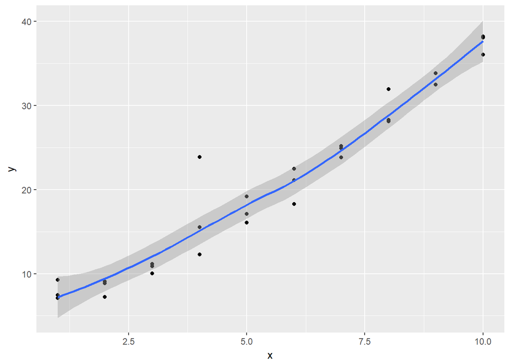

```r
sim1a_1 <- tibble(
  x = rep(1:10, each = 3),
  y = x **1.5 + 6 + rt(length(x), df = 2) )

sim1a_2 <- tibble(
  x = rep(1:10, each = 3),
  y = x **1.5 + 6 + rt(length(x), df = 2) )

sim1a_3 <- tibble(
  x = rep(1:10, each = 3),
  y = x **1.5 + 6 + rt(length(x), df = 2) )


sim1a_1 %>% ggplot(aes(x = x, y = y)) +
  geom_point() +
  geom_smooth()
```

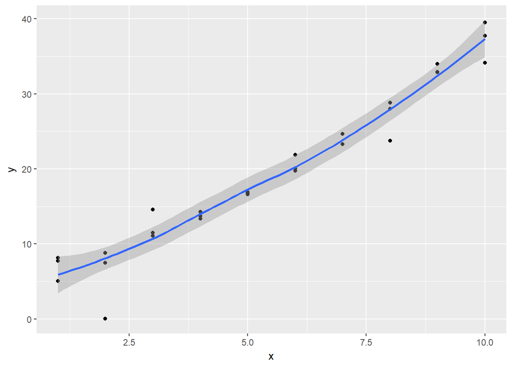

```r
sim1a_2 %>% ggplot(aes(x = x, y = y)) +
   geom_point() +
   geom_smooth()
```

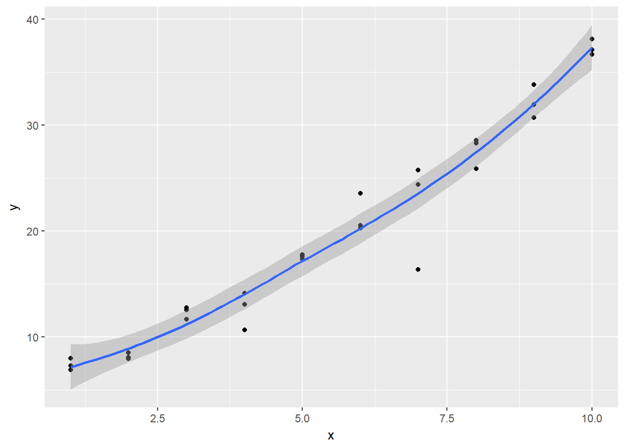

```r
sim1a_3 %>% ggplot(aes(x = x, y = y)) +
   geom_point() +
   geom_smooth()
```